# TYK Solution for TAME 2.0 Module 5.5, Unsupervised Machine Learning: Additional Clustering Applications

## TYK Questions

Using the same dataset as in the module (Module5_5_TYKInput.xlsx), answer the questions below.

1. Determine the optimal number of *k*-means clusters of cytokines derived from the nasal epithelieum lining fluid of **e-cigarette users**.
2. How do those clusters compare to the ones that were derived at baseline (in non-smokers)?
3. Which cytokines have the greatest contributions to the first two eigenvectors?

## Solution

```r
library(readxl)
library(factoextra)
library(FactoMineR)
library(tidyverse)
library(vegan)
library(reshape2)
suppressPackageStartupMessages(library(dendextend))
```

```r
# Reading in file
cytokines_df = data.frame(read_excel("Module5_5_TYKInput.xlsx", sheet = 2))

# Viewing data
head(cytokines_df)
```

```
##   Original_Identifier Group SubjectNo SubjectID Compartment Protein       Conc
## 1           E_C_F_002    NS         1      NS_1        NELF    IFNg  17.642316
## 2           E_C_F_002    NS         1      NS_1        NELF    IL10   2.873724
## 3           E_C_F_002    NS         1      NS_1        NELF IL12p70   1.625272
## 4           E_C_F_002    NS         1      NS_1        NELF    IL13  36.117692
## 5           E_C_F_002    NS         1      NS_1        NELF    IL1b 104.409217
## 6           E_C_F_002    NS         1      NS_1        NELF     IL6  21.159536
##   Conc_pslog2
## 1    4.220509
## 2    1.953721
## 3    1.392467
## 4    5.214035
## 5    6.719857
## 6    4.469856
```

### TYK Question 1

Determine the optimal number of *k*-means clusters of cytokines derived from the nasal epithelieum lining fluid of e-cigarette users.

Starting by performing the necessary data manipulation.

```r
# selecting NELF samples from ecig users
ecig_df = cytokines_df %>%
    filter(Group == "Ecig", Compartment == "NELF")

head(ecig_df)
```

```
##   Original_Identifier Group SubjectNo SubjectID Compartment Protein       Conc
## 1           E_B_F_053  Ecig        28   Ecig_28        NELF    IFNg  1.2327398
## 2           E_B_F_053  Ecig        28   Ecig_28        NELF    IL10  0.5417934
## 3           E_B_F_053  Ecig        28   Ecig_28        NELF IL12p70  3.6404802
## 4           E_B_F_053  Ecig        28   Ecig_28        NELF    IL13 11.1394299
## 5           E_B_F_053  Ecig        28   Ecig_28        NELF    IL1b 62.0491380
## 6           E_B_F_053  Ecig        28   Ecig_28        NELF     IL6 18.8312501
##   Conc_pslog2
## 1   1.1588152
## 2   0.6246094
## 3   2.2142741
## 4   3.6016288
## 5   5.9784047
## 6   4.3097037
```

```r
wider_ecig_df = reshape2::dcast(ecig_df, Protein ~ SubjectID, value.var = "Conc_pslog2") %>%
  column_to_rownames("Protein")

head(wider_ecig_df)
```

```
##                Ecig_28    Ecig_29    Ecig_30    Ecig_31   Ecig_32   Ecig_33
## Eotaxin      5.9560099  4.2058548  5.2052463  6.5184629  6.448992  8.383602
## Eotaxin3     3.6792233  5.3205450  3.8344973  2.9720881  3.791780 10.206203
## Fractalkine 12.4890149 11.4450722 12.8679559 13.8325772 13.339796 13.101722
## I309         0.0000000  0.0000000  0.0000000  0.0000000  0.000000  0.000000
## IFNg         1.1588152  3.1505320  1.4115786  0.0000000  2.114378  3.690171
## IL10         0.6246094  0.6577914  0.4176175  0.2069089  1.195176  2.607343
##               Ecig_34   Ecig_35    Ecig_36    Ecig_37   Ecig_38   Ecig_39
## Eotaxin      7.606646  7.513484  5.9542872  5.6178538  8.305834  7.873573
## Eotaxin3     4.345157  3.173294  2.7339420  3.2885361  5.239509  5.389172
## Fractalkine 15.205843 13.508127 11.8065072 12.2707738 13.410326 14.269303
## I309         0.000000  0.000000  0.0000000  0.0000000  0.000000  0.000000
## IFNg         2.344551  3.594729  0.8305996  1.6781974  3.476850  4.038599
## IL10         0.773740  2.505931  1.4673188  0.7844336  1.915382  2.440282
##               Ecig_40   Ecig_41   Ecig_42   Ecig_43   Ecig_44
## Eotaxin      7.820937  6.495279  6.247441  7.598287  6.197323
## Eotaxin3     7.519071  5.216470  2.659909  6.938425  3.074016
## Fractalkine 13.912916 12.127709 11.103226 11.887413 13.210056
## I309         0.786099  0.000000  0.000000  2.547325  0.000000
## IFNg         3.762679  3.777575  0.000000  4.004199  2.176177
## IL10         2.103872  1.993043  0.372858  2.457847  1.121557
```

Finding the “best” number of clusters to use.

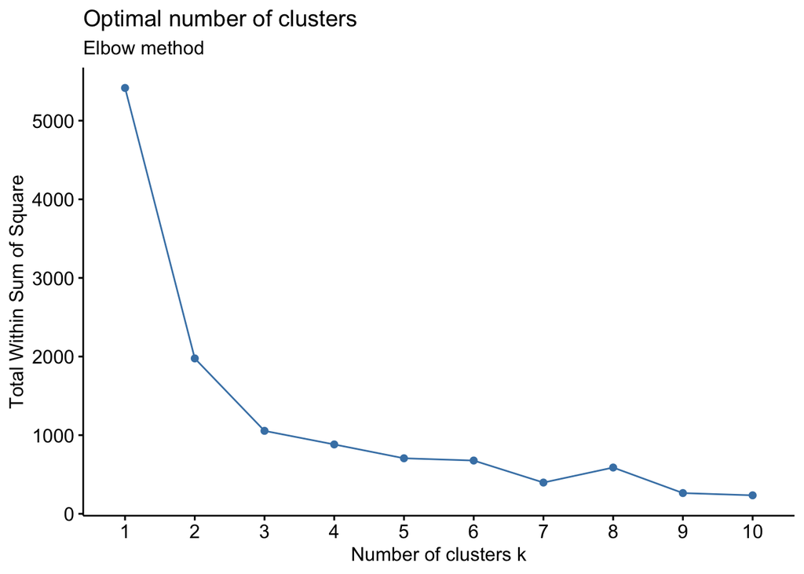

```r
# Elbow method
fviz_nbclust(wider_ecig_df, kmeans, method = "wss") +
  labs(subtitle = "Elbow method")
```

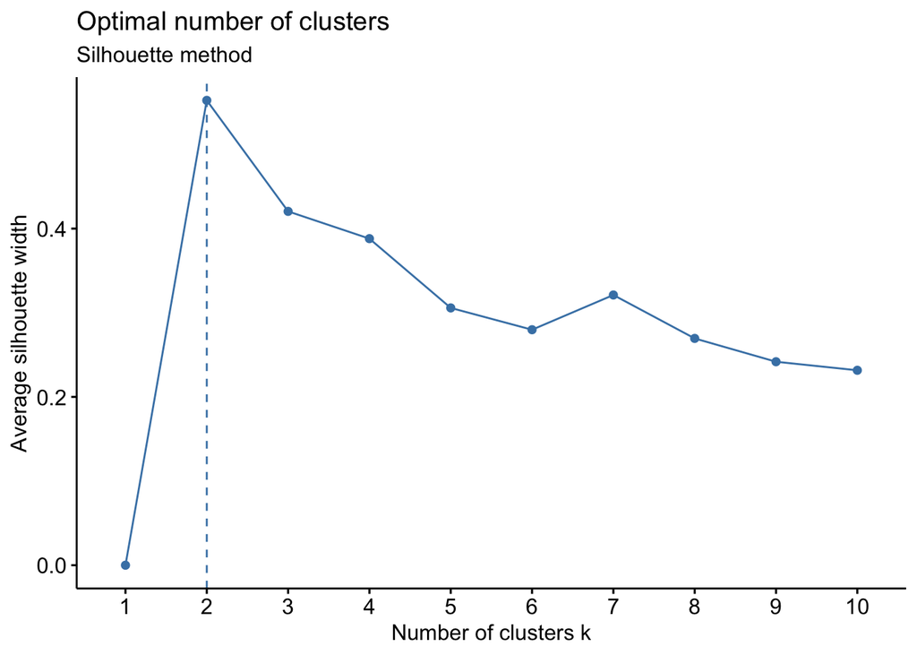

```r
# Silhouette method
fviz_nbclust(wider_ecig_df, kmeans, method = "silhouette") +
  labs(subtitle = "Silhouette method")
```

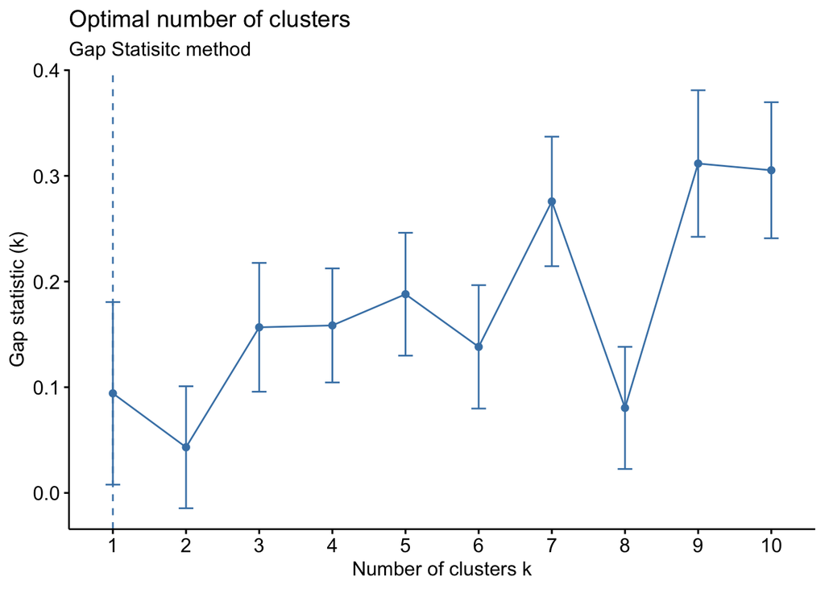

```r
# Gap statistic method
fviz_nbclust(wider_ecig_df, kmeans, method = "gap_stat") +
  labs(subtitle = "Gap Statisitc method")
```

The elbow method is suggesting 3 clusters, the silhouette method is suggesting 2, and the gap statistic method suggests 1. Since each of these methods is recommending different *k* values, we can go ahead and run *k*-means to visualize the clusters and test those different *k*’s.

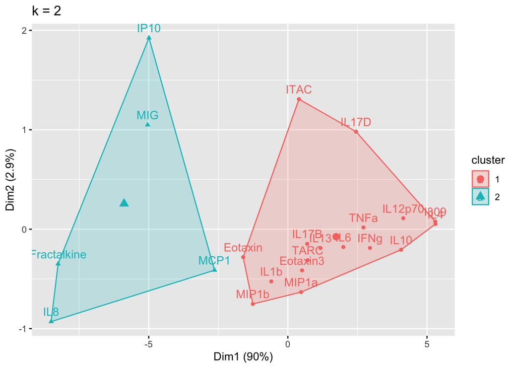

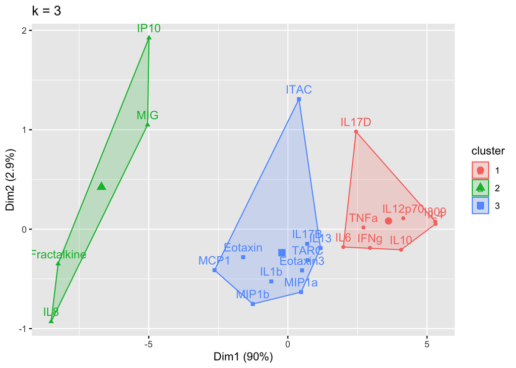

```r
# Choosing to iterate through 2 or 3 clusters using i as our iterator
for (i in 2:3){
    # nstart = number of random starting partitions, it's recommended for nstart > 1
    cluster_k <- kmeans(wider_ecig_df, centers = i, nstart = 25)
    cluster_plot <- fviz_cluster(cluster_k, data = wider_ecig_df) + ggtitle(paste0("k = ", i))
    print(cluster_plot)
}
```

**Answer**: 2 or 3 clusters could be justified here, but we’ll move forward with 3 clusters to more easily compare to the non-smoker clusters.

### TYK Question 2

How do those clusters compare to the ones that were derived at baseline (in non-smokers)?

This question can be answer by obtaining the cluster assignments.

```r
# getting cluster assignments
cluster_kmeans_3 <- kmeans(wider_ecig_df, centers = 3, nstart = 25)
cluster_kmeans_df <- data.frame(cluster_kmeans_3$cluster) %>%
    rownames_to_column("Cytokine") %>%
    rename(`K-Means Cluster` = cluster_kmeans_3.cluster) %>%
    # Ordering the dataframe for easier comparison
    arrange(`K-Means Cluster`)

cluster_kmeans_df
```

```
##       Cytokine K-Means Cluster
## 1      Eotaxin               1
## 2     Eotaxin3               1
## 3         IL13               1
## 4        IL17B               1
## 5         IL1b               1
## 6         ITAC               1
## 7         MCP1               1
## 8        MIP1a               1
## 9        MIP1b               1
## 10        TARC               1
## 11        I309               2
## 12        IFNg               2
## 13        IL10               2
## 14     IL12p70               2
## 15       IL17D               2
## 16         IL4               2
## 17         IL6               2
## 18        TNFa               2
## 19 Fractalkine               3
## 20         IL8               3
## 21        IP10               3
## 22         MIG               3
```

**Answer**: All cytokines clustered together as they did in non-smoking subjects with the exception IL-6, which moved from cluster 1 to cluster 2.

### TYK Question 3

Which cytokines have the greatest contributions to the first two eigenvectors?

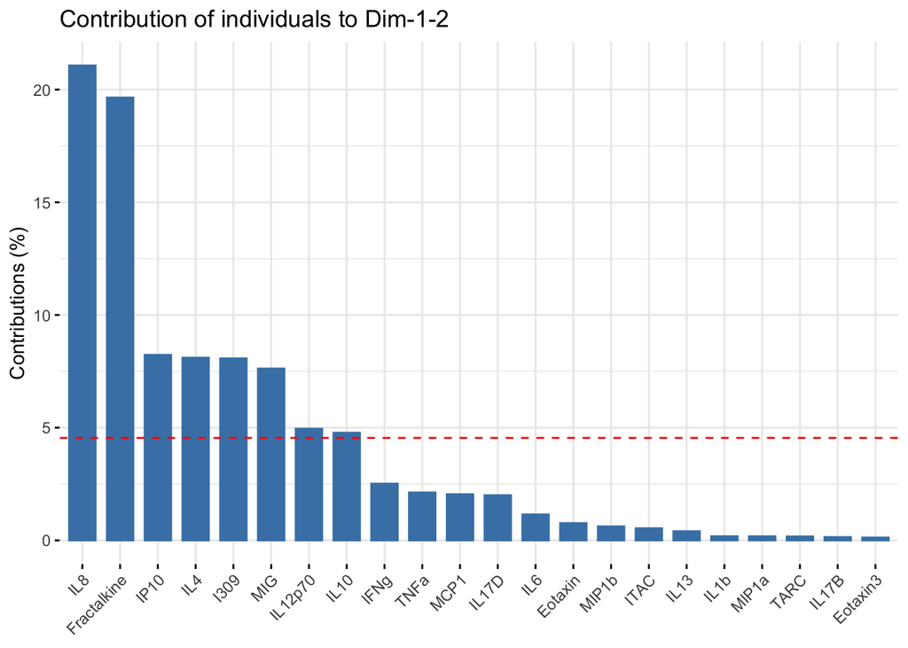

```r
# First running PCA
pca_cytokine <- prcomp(wider_ecig_df, scale = TRUE, center = TRUE)

# kmeans contributions
fviz_contrib(pca_cytokine,
             choice = "ind",
             axes = 1:2) # specifies to show contribution percentages for first 2 PCs
```

**Answer**: The cytokines that have the greatest contributions to the first two principal components include IL-8, Fractalkine, IP-10, IL-4, MIG, I309, IL-12p70, and IL-10.